# Conference Report: LatinR 2018

The ‘Conference Report: LatinR 2018’ article from the 2018-2 issue.

Laura Acion (Chair of LatinR2018) , Natalia da Silva (Chair of LatinR2018) , Riva Quiroga (Chair of LatinR2018)  
2018-12-01

## 1 Conference summary

`LatinR <- Latin American Conference about the Use of R in Research + Development` (LatinR) was an international conference which goal was bringing together the Latin American R community. LatinR took place for the first time at the Universidad de Palermo in Buenos Aires, Argentina, on September 3 to 5, 2018. About 100 participants from more than 10 different countries (e.g., Argentina, Uruguay, Chile, Peru, Ecuador, Brazil, Costa Rica, Venezuela, Spain, United States, Canada) attended LatinR.

LatinR will be an annual meeting that will rotate among different countries in Latin America. LatinR 2019 will be hosted by the Universidad Católica de Chile in Santiago de Chile on September 25 to 27.

## 2 Getting started

Up to now, Latin America never hosted a useR! conference. Until 2017, only Brazil, the biggest Latin American country, had some events gathering the local R community (i.e., R Day - Encontro Nacional de Usuários do R and SER - International Seminar on Statistics with R).

On October 25, 2017, an announcement was made by Heather Turner on the R User Group (RUG) Organizers Slack: "the R Foundation Conference Committee would like to see academic-focused R events in regions not currently covered by useR!" In less than a week, a group of academic Latin American R-Ladies organized their first conference call to start thinking about how this challenge could be achieved. This fast response was not the result of mere chance, but the consequence of a year in which the R community grew stronger in South America. By mid-November, everything was set up: a name, a place, a date, and a motivated international organizing committee.

To ease the organizational load of its first edition, LatinR 2018 was hosted within the 47th Argentinean Meetings of Informatics and Operational Research (JAIIO). JAIIO usually includes about 13 simultaneous meetings over five days and is organized by the Argentinean Informatics Society (SADIO). The 47th JAIIO was not only the organizational umbrella under which LatinR 2018 took place but also the first time JAIIO had a Code of Conduct (CoC). The CoC was requested by the R Foundation, one of LatinR endorsers, and was written by LatinR organizers for all meetings within JAIIO.

## 3 Program

LatinR had three official languages: Spanish, Portuguese, and English. It received submissions in the three languages and had presentations also in all three languages. September 3rd was dedicated to three half-day hands-on tutorials:

- Natalia da Silva: Static and interactive visualization with ggplot2 and plotly
- Andrés Farall: Introduction to deep learning with R
- Jenny Bryan: How to repeat yourself with purrr

LatinR 2018 also had two outstanding plenary talks: "The Zen and the Art of Workflow Maintenance" by Jenny Bryan and "Aprender a Computar vs. Computar para Aprender" by Walter Sosa Escudero. Bryan presented the interaction between Statistics and Data Science and several practical tips to learn, improve, and maintain good data workflows with R. On the other hand, Sosa Escudero showed some examples about how teaching statistics can benefit by incorporating R programming in theoretical Statistics courses. Both plenary talks complemented each other and left a clear message about the need to embrace changes both when teaching and practicing Statistics and Data Science.

LatinR received 93 abstracts from several different countries. Only 62 abstracts were accepted, 32 of them were 15-minute oral presentations and the rest of the accepted abstracts were presented in a poster session. Figure 1 shows a bar plot with the abstract submission country distribution based on first author origin. Most of the submissions were from South America (Argentina, Uruguay, Peru, and Brazil). Nine out of the 32 oral presentations (28%) were conducted by women or other under-represented minorities (URM) in the R community. Seventeen out of the 30 posters (56%) had women or URM as first authors and out of the 8 invited talks, 6 were presented by women (75%). That is, out of all 40 oral presentations, 38% were presented by women or URM.

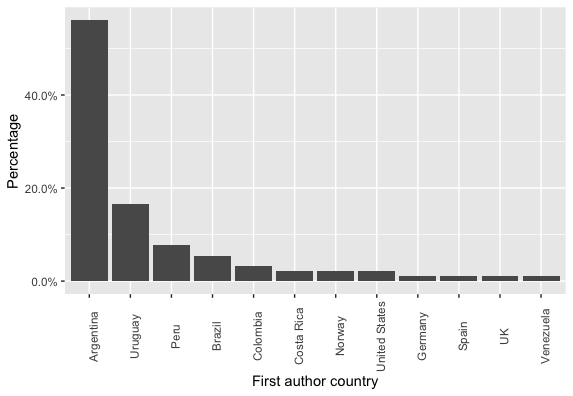

Figure 1: LatinR 2018 abstract submission distribution by first author country

Topics presented included applications of R in academic and industry settings throughout a wide number of fields such as Data Science, Statistics, Informatics, Biological and Health Sciences, Atmospheric Sciences, Social Sciences, Humanities, Economics, and Creativity. Talks and posters encompassed, among others, new R packages, innovative uses of R in Education, R visualization tools, and open data analysis with R.

The program also included presentations by members of vibrant communities within the R ecosystem such as Global and Latin American R-Ladies and The Carpentries. One of LatinR tracks during Wednesday morning was a summary tutorial about how to become a Carpentries instructor including 28 attendees. Wednesday was the moment of rOpenSci represented by Maëlle Salmon via teleconference and a live Q&A session led by Jenny Bryan. R user groups were also represented on Wednesday by Joshua Kunst from the Santiago de Chile RUG. The Spanish-speaking community efforts for translating R for Data Science (R4DS) (Wickham and Grolemund 2017) was also presented by Riva Quiroga, one of the project leaders.

LatinR had a very important networking role. For instance, its three chairs, almost all its organizers, volunteers, and many community members (such as those working on the translation of R4DS) who were used to working together virtually, got to meet in person for the first time during the conference. Additionally, LatinR impulsed the community in the region in the form of at least three new RUGs that just launched in Rosario, Montevideo, and Buenos Aires.

LatinR also collaborated in a JAIIO-wide activity that debated during two hours the participation of women in sciences, technology, engineer and math. Six women from varied backgrounds presented their views about this topic and discussed them with the attendees.

## 4 Scientific and organizing committees

LatinR was possible thanks to the effort of a highly motivated and compromised team of about 80 people including: 3 chairs (100% women from 3 Latin American countries), a 36-member scientific committee (44% women or URM; representing 8 countries around the globe), the SADIO organizing team (88% women), and a 16-member LatinR organizing committee (88% women; representing 6 Latin American countries). In addition, a highly motivated group of 15 volunteers (66% women) helped the conference run smoothly. Among all these people, Yanina Bellini Saibene, Elio Campitelli, Paola Corrales, and Florencia D’Andrea received the Chairs’ Recognition Award for their outstanding and continuous contribution since the very beginning of LatinR.

## 5 Sponsors

LatinR was also possible to the following sponsors: RStudio, Fundación Sadosky, Escuelas Argentinas de Nuevas Tecnologı́as, R Consortium, DataCamp, and IBM Argentina.

## 6 Further information

- Video of Jenny Bryan plenary talk: https://bit.ly/2EIRaEs
- Video of Walter Sosa Escudero plenary talk: https://bit.ly/2RfwW6F
- LatinR presentations: https://github.com/LatinR/presentaciones-LatinR2018
- Twitter account: @LatinR_Conf #LatinR2018
- Webpage: http://latin-r.com

H. Wickham and G. Grolemund. *R for data science: Import, tidy, transform, visualize, and model data.* Sebastopol, CA, USA: O’Reilly Media, Inc., 2017. URL https://r4ds.had.co.nz/. ISBN-13 978-1491910399.